# BIOSTAT 707 Checkpoint 1: Cohort Characterization and EDA

Author

Jiahui Hu (jh1029)

Published

September 18, 2026

```r
suppressPackageStartupMessages({
  library(data.table)
  library(dplyr)
  library(tidyr)
  library(readr)
  library(ggplot2)
  library(gtsummary)
  library(knitr)
})

here::i_am("checkpoint1.qmd")

data_dir     <- here::here("data")
set_a_dir    <- here::here("data", "set-a")
outcomes_csv <- here::here("data", "Outcomes-a.txt")
out_dir      <- here::here("output")
dir.create(out_dir, recursive = TRUE, showWarnings = FALSE)

expected_n <- 4000L

theme_set(
  theme_minimal(base_size = 12) +
    theme(panel.grid.minor = element_blank())
)
```

# Reproducible data checks

```r
check_set_a <- function(set_a_dir, outcomes_csv, expected_n = 4000L) {
  if (!dir.exists(set_a_dir)) {
    stop(
      "Missing directory: ", set_a_dir,
      "\nExpected 4000 files under data/set-a/."
    )
  }

  if (!file.exists(outcomes_csv)) {
    stop("Missing outcomes file: ", outcomes_csv)
  }

  files <- sort(list.files(
    set_a_dir,
    pattern = "^[0-9]+\\.txt$",
    full.names = TRUE
  ))

  if (length(files) != expected_n) {
    stop(
      "Expected ", expected_n, " patient files in data/set-a/, but found ",
      length(files), "."
    )
  }

  files
}

set_a_files <- check_set_a(set_a_dir, outcomes_csv, expected_n)
```

# Load and combine the 4,000 skinny files

Each source file contains a pseudo-measurement whose `Parameter` is `RecordID`. I use that row only to verify the filename, then remove it and keep `RecordID` as an identifier column. This is important: if the pseudo-measurement is allowed into `pivot_wider()`, it attempts to create a new column named `RecordID` next to the existing identifier column and produces the duplicated name error.

```r
time_to_minutes <- function(x) {
  pieces <- strsplit(x, ":", fixed = TRUE)
  vapply(
    pieces,
    function(z) {
      if (length(z) != 2L) return(NA_real_)
      hour <- suppressWarnings(as.numeric(z[[1]]))
      minute <- suppressWarnings(as.numeric(z[[2]]))
      if (is.na(hour) || is.na(minute)) return(NA_real_)
      60 * hour + minute
    },
    numeric(1)
  )
}

load_one_record <- function(path) {
  record_id_from_file <- suppressWarnings(as.integer(
    sub("\\.txt$", "", basename(path))
  ))

  if (is.na(record_id_from_file)) {
    stop("Could not obtain RecordID from filename: ", path)
  }

  x <- data.table::fread(
    path,
    sep = ",",
    header = TRUE,
    showProgress = FALSE
  )

  names(x) <- trimws(names(x))
  required <- c("Time", "Parameter", "Value")
  if (!all(required %in% names(x))) {
    stop("File does not contain Time, Parameter, and Value: ", path)
  }

  x[, Parameter := trimws(as.character(Parameter))]
  x[, Time := trimws(as.character(Time))]
  x[, Value := suppressWarnings(as.numeric(Value))]

  embedded_id <- x[Parameter == "RecordID", Value]
  if (length(embedded_id) != 1L ||
      is.na(embedded_id[[1]]) ||
      as.integer(embedded_id[[1]]) != record_id_from_file) {
    stop("RecordID row does not match filename in: ", path)
  }

  # Critical fix for the duplicated RecordID error.
  x <- x[Parameter != "RecordID"]
  x[, RecordID := record_id_from_file]

  x[, .(
    RecordID,
    Time,
    Minutes = time_to_minutes(Time),
    Parameter,
    Value_raw = Value
  )]
}

long_raw <- data.table::rbindlist(
  lapply(set_a_files, load_one_record),
  use.names = TRUE,
  fill = FALSE
) |>
  as_tibble()

if (anyNA(long_raw$Minutes)) {
  bad_times <- unique(long_raw$Time[is.na(long_raw$Minutes)])
  stop("Unparseable time value(s): ", paste(bad_times, collapse = ", "))
}

stopifnot(
  "RecordID must not remain as a Parameter" =
    !any(long_raw$Parameter == "RecordID"),
  "The long table must contain 4,000 records" =
    n_distinct(long_raw$RecordID) == expected_n
)
```

```r
outcomes <- readr::read_csv(
  outcomes_csv,
  show_col_types = FALSE,
  progress = FALSE
)

# Normalize punctuation in names, e.g. SAPS-I -> SAPS_I and
# In-hospital_death -> In_hospital_death.
names(outcomes) <- gsub("[^A-Za-z0-9]+", "_", names(outcomes))
names(outcomes) <- gsub("_+$", "", names(outcomes))

required_outcomes <- c(
  "RecordID", "SAPS_I", "SOFA", "Length_of_stay",
  "Survival", "In_hospital_death"
)

if (!all(required_outcomes %in% names(outcomes))) {
  stop(
    "Outcomes-a.txt is missing required columns. Found: ",
    paste(names(outcomes), collapse = ", ")
  )
}

outcomes <- outcomes |>
  mutate(
    RecordID = as.integer(RecordID),
    In_hospital_death = as.integer(In_hospital_death)
  )

stopifnot(
  "Outcomes must contain one row per record" =
    !anyDuplicated(outcomes$RecordID),
  "Outcomes must contain 4,000 records" =
    nrow(outcomes) == expected_n,
  "Measurement and outcome IDs must agree" =
    setequal(long_raw$RecordID, outcomes$RecordID),
  "Death outcome must be coded 0/1" =
    all(outcomes$In_hospital_death %in% c(0L, 1L))
)

id_frame <- outcomes |>
  distinct(RecordID) |>
  arrange(RecordID)
```

# Data-quality decisions

The value `-1` is the dataset’s missing-value sentinel, so I convert it to an R missing value. I also screen selected variables using deliberately broad bounds. These are data-quality bounds, not normal clinical reference ranges. Values outside them are retained in `Value_raw`, flagged, and excluded only from numerical summaries through `Value_clean`. This makes the handling of questionable values auditable rather than silently deleting source rows.

```r
quality_bounds <- tribble(
  ~Parameter,    ~lower, ~upper,
  "Age",             0,    130,
  "Gender",          0,      1,
  "Height",         50,    250,
  "ICUType",         1,      4,
  "Weight",         20,    400,
  "Albumin",         0,     20,
  "ALP",             0,   5000,
  "ALT",             0,  20000,
  "AST",             0,  20000,
  "Bilirubin",       0,    100,
  "BUN",             0,    300,
  "Cholesterol",     0,   1000,
  "Creatinine",      0,     30,
  "DiasABP",         0,    250,
  "FiO2",            0,      1,
  "GCS",             3,     15,
  "Glucose",         0,   2000,
  "HCO3",            0,    100,
  "HCT",             0,    100,
  "HR",              0,    300,
  "K",               0,     15,
  "Lactate",         0,     40,
  "MAP",             0,    250,
  "MechVent",        0,      1,
  "Mg",              0,     20,
  "Na",             80,    220,
  "NIDiasABP",       0,    250,
  "NIMAP",           0,    250,
  "NISysABP",        0,    300,
  "PaCO2",           0,    300,
  "PaO2",            0,    800,
  "pH",              0,     14,
  "Platelets",       0,   2000,
  "RespRate",        0,    100,
  "SaO2",            0,    100,
  "SysABP",          0,    300,
  "Temp",           25,     45,
  "TroponinI",       0,   1000,
  "TroponinT",       0,   1000,
  "Urine",           0,  10000,
  "WBC",             0,    500
)

long <- long_raw |>
  left_join(quality_bounds, by = "Parameter") |>
  mutate(
    is_sentinel_missing = !is.na(Value_raw) & Value_raw == -1,
    Value = if_else(is_sentinel_missing, NA_real_, Value_raw),
    is_nonfinite = !is.na(Value) & !is.finite(Value),
    is_implausible =
      !is.na(Value) & !is.na(lower) & !is.na(upper) &
      (Value < lower | Value > upper),
    quality_issue = case_when(
      is_nonfinite ~ "non-finite",
      is_implausible ~ "outside broad data-quality bound",
      TRUE ~ NA_character_
    ),
    Value_clean = if_else(is_nonfinite | is_implausible, NA_real_, Value)
  ) |>
  arrange(RecordID, Minutes, Parameter)

quality_summary <- long |>
  filter(!is.na(quality_issue)) |>
  count(Parameter, quality_issue, name = "flagged_rows", sort = TRUE)

if (nrow(quality_summary) == 0L) {
  quality_summary <- tibble(
    Parameter = "None",
    quality_issue = "No values were flagged",
    flagged_rows = 0L
  )
}

knitr::kable(
  quality_summary,
  caption = "Values flagged by the transparent data-quality rules"
)
```

Values flagged by the transparent data-quality rules

| Parameter | quality_issue | flagged_rows |
| --- | --- | --- |
| Weight | outside broad data-quality bound | 235 |
| Temp | outside broad data-quality bound | 130 |
| MAP | outside broad data-quality bound | 93 |
| Height | outside broad data-quality bound | 16 |
| pH | outside broad data-quality bound | 9 |
| DiasABP | outside broad data-quality bound | 3 |
| K | outside broad data-quality bound | 2 |
| Urine | outside broad data-quality bound | 1 |

```r
set_a_long <- long |>
  select(
    RecordID, Time, Minutes, Parameter,
    Value_raw, Value, Value_clean,
    is_sentinel_missing, is_implausible, quality_issue
  )

readr::write_csv(
  set_a_long,
  file.path(out_dir, "set-a_long.csv"),
  na = ""
)
```

The combined table contains 1,753,980 measurement rows from 4000 ICU stays and 41 measured parameters.

# What exists at prediction time

The prediction window consists of measurements recorded during the first 48 hours of the ICU stay. The outcome variables in `Outcomes-a.txt` are used here only to describe the cohort and investigate associations; they are not predictors available at the prediction time. To retain timing while creating a one-row-per-stay table, I summarize repeated measurements separately in two landmark windows: 0–24 hours and 24–48 hours.

No outcome-based imputation or feature selection is performed in this checkpoint. Absence of a measurement may reflect both patient physiology and the clinical team’s decision to order a test, so missingness indicators are preserved rather than immediately imputed away.

# Baseline cohort and Table 1

```r
first_nonmissing <- function(x) {
  y <- x[!is.na(x)]
  if (length(y) == 0L) NA_real_ else y[[1]]
}

static_parameters <- c("Age", "Gender", "Height", "ICUType", "Weight")

static <- long |>
  filter(Parameter %in% static_parameters) |>
  arrange(RecordID, Minutes) |>
  group_by(RecordID, Parameter) |>
  summarise(Value = first_nonmissing(Value_clean), .groups = "drop") |>
  pivot_wider(
    id_cols = RecordID,
    names_from = Parameter,
    values_from = Value,
    names_repair = "check_unique"
  ) |>
  right_join(id_frame, by = "RecordID") |>
  arrange(RecordID)

table1_data <- static |>
  left_join(outcomes, by = "RecordID") |>
  mutate(
    Gender = factor(
      Gender,
      levels = c(0, 1),
      labels = c("Female", "Male")
    ),
    ICUType = factor(
      ICUType,
      levels = c(1, 2, 3, 4),
      labels = c(
        "Coronary care unit",
        "Cardiac surgery recovery unit",
        "Medical ICU",
        "Surgical ICU"
      )
    ),
    In_hospital_death = factor(
      In_hospital_death,
      levels = c(0, 1),
      labels = c("Survived", "Died")
    )
  )
```

```r
table1_data |>
  select(
    In_hospital_death,
    Age, Gender, ICUType, Height, Weight, SAPS_I, SOFA
  ) |>
  gtsummary::tbl_summary(
    by = In_hospital_death,
    missing = "ifany",
    statistic = list(
      all_continuous() ~ "{median} ({p25}, {p75})",
      all_categorical() ~ "{n} ({p}%)"
    ),
    digits = all_continuous() ~ 1,
    label = list(
      Age ~ "Age (years)",
      Gender ~ "Sex",
      ICUType ~ "ICU type",
      Height ~ "Height (cm)",
      Weight ~ "Weight (kg)",
      SAPS_I ~ "SAPS-I",
      SOFA ~ "SOFA"
    )
  ) |>
  gtsummary::add_overall(last = FALSE) |>
  gtsummary::bold_labels() |>
  gtsummary::modify_caption(
    "**Table 1. Baseline cohort characteristics by in-hospital outcome**"
  )
```

**Table 1. Baseline cohort characteristics by in-hospital outcome**

| **Characteristic** | **Overall** N = 4,000<sup>1</sup> | **Survived** N = 3,446<sup>1</sup> | **Died** N = 554<sup>1</sup> |
| --- | --- | --- | --- |
| Age (years) | 67.0 (52.5, 78.0) | 66.0 (51.0, 78.0) | 74.0 (60.0, 83.0) |
| Sex |  |  |  |
| Female | 1,751 (44%) | 1,498 (43%) | 253 (46%) |
| Male | 2,246 (56%) | 1,946 (57%) | 300 (54%) |
| Unknown | 3 | 2 | 1 |
| ICU type |  |  |  |
| Coronary care unit | 577 (14%) | 496 (14%) | 81 (15%) |
| Cardiac surgery recovery unit | 874 (22%) | 831 (24%) | 43 (7.8%) |
| Medical ICU | 1,481 (37%) | 1,206 (35%) | 275 (50%) |
| Surgical ICU | 1,068 (27%) | 913 (26%) | 155 (28%) |
| Height (cm) | 170.2 (162.6, 177.8) | 170.2 (162.6, 177.8) | 170.2 (160.0, 177.8) |
| Unknown | 1,910 | 1,617 | 293 |
| Weight (kg) | 78.6 (66.0, 92.0) | 79.1 (66.4, 92.4) | 75.0 (62.0, 90.0) |
| Unknown | 296 | 271 | 25 |
| SAPS-I | 15.0 (11.0, 18.0) | 14.0 (10.0, 18.0) | 17.0 (13.0, 21.0) |
| SOFA | 6.0 (3.0, 9.0) | 6.0 (3.0, 9.0) | 8.0 (5.0, 11.0) |

<sup>1</sup> Median (Q1, Q3); n (%)

# Outcome summary

```r
outcome_summary <- outcomes |>
  summarise(
    Records = n(),
    Deaths = sum(In_hospital_death == 1L),
    `Death rate (%)` = 100 * mean(In_hospital_death == 1L),
    `Length of stay, median` = median(Length_of_stay, na.rm = TRUE),
    `Length of stay, Q1` = quantile(Length_of_stay, 0.25, na.rm = TRUE),
    `Length of stay, Q3` = quantile(Length_of_stay, 0.75, na.rm = TRUE),
    `SAPS-I, median` = median(SAPS_I, na.rm = TRUE),
    `SOFA, median` = median(SOFA, na.rm = TRUE)
  ) |>
  mutate(across(where(is.numeric), ~ round(.x, 1)))

knitr::kable(
  outcome_summary,
  caption = "Overall outcome and severity summary"
)
```

Overall outcome and severity summary

| Records | Deaths | Death rate (%) | Length of stay, median | Length of stay, Q1 | Length of stay, Q3 | SAPS-I, median | SOFA, median |
| --- | --- | --- | --- | --- | --- | --- | --- |
| 4000 | 554 | 13.9 | 10 | 6 | 17 | 15 | 6 |

There were 554 in-hospital deaths among 4000 stays, corresponding to a mortality proportion of 13.9%.

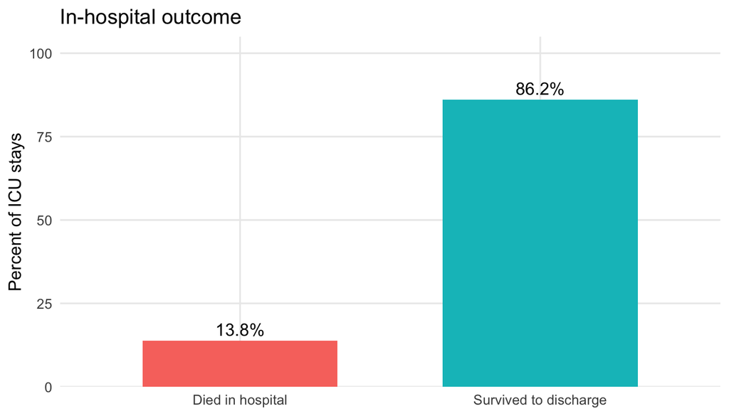

```r
outcomes |>
  count(In_hospital_death) |>
  mutate(
    Outcome = if_else(
      In_hospital_death == 1L,
      "Died in hospital",
      "Survived to discharge"
    ),
    Percent = 100 * n / sum(n)
  ) |>
  ggplot(aes(x = Outcome, y = Percent, fill = Outcome)) +
  geom_col(width = 0.65, show.legend = FALSE) +
  geom_text(
    aes(label = sprintf("%.1f%%", Percent)),
    vjust = -0.4
  ) +
  scale_y_continuous(
    limits = c(0, 100),
    expand = expansion(mult = c(0, 0.05))
  ) +
  labs(x = NULL, y = "Percent of ICU stays", title = "In-hospital outcome")
```

# Build the landmark-stacked wide table

```r
# Age, Gender, Height, and ICUType are baseline descriptors. Weight can be
# repeated, so it remains in the longitudinal summaries as well as Table 1.
nonlongitudinal_parameters <- c("Age", "Gender", "Height", "ICUType")

analysis_long <- long |>
  filter(
    between(Minutes, 0, 48 * 60),
    !Parameter %in% nonlongitudinal_parameters,
    !is.na(Value_clean)
  ) |>
  mutate(
    Window = if_else(Minutes < 24 * 60, "h00_24", "h24_48")
  ) |>
  arrange(RecordID, Parameter, Window, Minutes)

summary_long <- analysis_long |>
  group_by(RecordID, Parameter, Window) |>
  summarise(
    count = n(),
    first = dplyr::first(Value_clean),
    last = dplyr::last(Value_clean),
    min = min(Value_clean),
    max = max(Value_clean),
    mean = mean(Value_clean),
    .groups = "drop"
  )

duplicate_keys <- summary_long |>
  count(RecordID, Parameter, Window, name = "rows") |>
  filter(rows > 1L)

stopifnot(
  "RecordID must never be expanded from Parameter" =
    !any(summary_long$Parameter == "RecordID"),
  "Each RecordID/Parameter/window key must be unique" =
    nrow(duplicate_keys) == 0L
)

wide_ts <- summary_long |>
  pivot_wider(
    id_cols = RecordID,
    names_from = c(Parameter, Window),
    values_from = c(count, first, last, min, max, mean),
    names_glue = "{Parameter}_{Window}_{.value}",
    names_sort = TRUE,
    names_repair = "check_unique"
  )

set_a_wide <- id_frame |>
  left_join(static, by = "RecordID") |>
  left_join(wide_ts, by = "RecordID") |>
  left_join(outcomes, by = "RecordID")

# A count of zero is meaningful; other summaries remain NA when unmeasured.
count_columns <- grep("_count$", names(set_a_wide), value = TRUE)
set_a_wide <- set_a_wide |>
  mutate(across(all_of(count_columns), ~ replace_na(.x, 0)))

stopifnot(
  "Wide table must have 4,000 rows" = nrow(set_a_wide) == expected_n,
  "Wide table must have one row per RecordID" =
    !anyDuplicated(set_a_wide$RecordID),
  "Wide-table column names must be unique" =
    !anyDuplicated(names(set_a_wide))
)

readr::write_csv(
  set_a_wide,
  file.path(out_dir, "set-a_wide.csv"),
  na = ""
)
```

The wide table has 4000 rows and 455 columns. It contains one row per ICU stay, baseline descriptors, outcomes, and separate 0–24-hour and 24–48-hour summaries for repeated measurements.

# Missingness using temporal information

For each six-hour block, the heat map below shows the percentage of the 4,000 stays with at least one valid observation. A blank test is therefore treated as an absence of measurement, not as a numeric zero.

```r
time_labels <- c(
  "00-06h", "06-12h", "12-18h", "18-24h",
  "24-30h", "30-36h", "36-42h", "42-48h"
)

measured_by_block <- long |>
  filter(
    between(Minutes, 0, 48 * 60),
    !Parameter %in% nonlongitudinal_parameters,
    !is.na(Value_clean)
  ) |>
  mutate(
    Time_block = cut(
      Minutes,
      breaks = c(seq(0, 42 * 60, by = 6 * 60), 48 * 60 + 1),
      labels = time_labels,
      right = FALSE,
      include.lowest = TRUE
    )
  ) |>
  distinct(RecordID, Parameter, Time_block)

parameter_order <- measured_by_block |>
  count(Parameter, name = "observed_patient_blocks") |>
  arrange(observed_patient_blocks) |>
  pull(Parameter)

temporal_missingness <- measured_by_block |>
  count(Parameter, Time_block, name = "records_measured") |>
  complete(
    Parameter,
    Time_block = factor(time_labels, levels = time_labels),
    fill = list(records_measured = 0L)
  ) |>
  mutate(
    percent_measured = 100 * records_measured / expected_n,
    Parameter = factor(Parameter, levels = parameter_order),
    Time_block = factor(Time_block, levels = time_labels)
  )
```

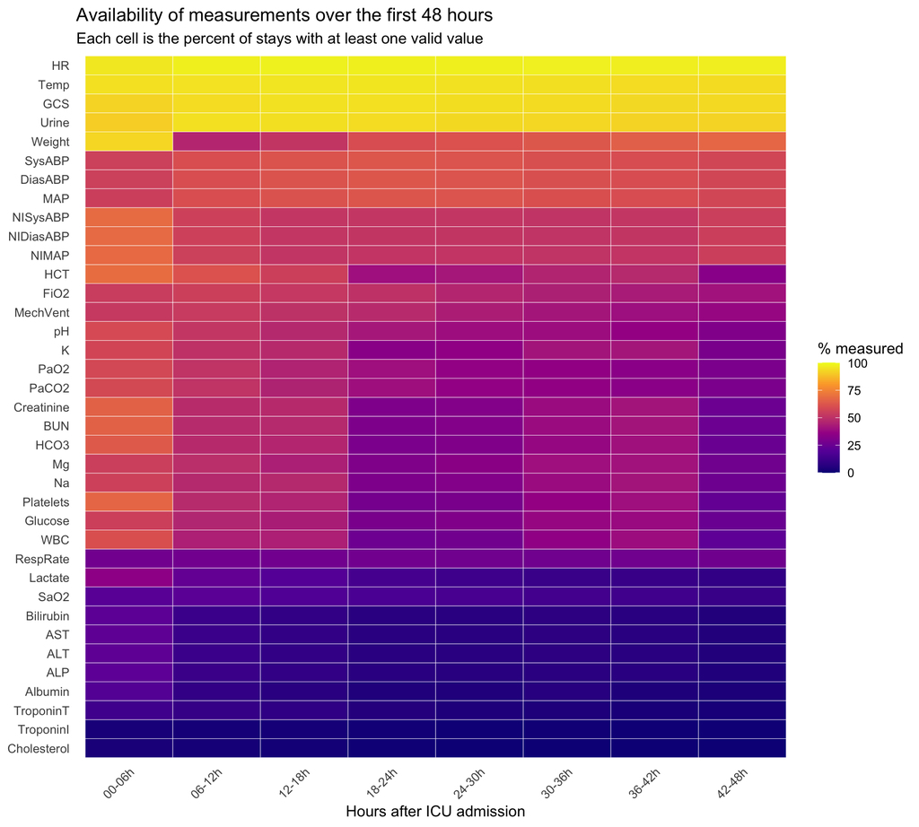

```r
ggplot(
  temporal_missingness,
  aes(x = Time_block, y = Parameter, fill = percent_measured)
) +
  geom_tile(color = "white", linewidth = 0.15) +
  scale_fill_viridis_c(
    option = "C",
    limits = c(0, 100),
    name = "% measured"
  ) +
  labs(
    x = "Hours after ICU admission",
    y = NULL,
    title = "Availability of measurements over the first 48 hours",
    subtitle = "Each cell is the percent of stays with at least one valid value"
  ) +
  theme(
    axis.text.x = element_text(angle = 45, hjust = 1),
    panel.grid = element_blank()
  )
```

# Missingness in the wide table

The next graph uses the numerical summary columns rather than the count columns. Counts are explicitly zero when no value was measured; `first`, `last`, `min`, `max`, and `mean` remain missing in that situation.

```r
summary_value_columns <- grep(
  "_(first|last|min|max|mean)$",
  names(set_a_wide),
  value = TRUE
)

wide_missingness <- tibble(
  Variable = summary_value_columns,
  Missing_percent = 100 * vapply(
    set_a_wide[summary_value_columns],
    function(x) mean(is.na(x)),
    numeric(1)
  )
) |>
  arrange(desc(Missing_percent))

top_wide_missingness <- wide_missingness |>
  slice_head(n = 30L) |>
  mutate(Variable = factor(Variable, levels = rev(Variable)))

patient_missingness <- tibble(
  RecordID = set_a_wide$RecordID,
  Missing_percent = 100 * rowMeans(is.na(set_a_wide[summary_value_columns]))
)
```

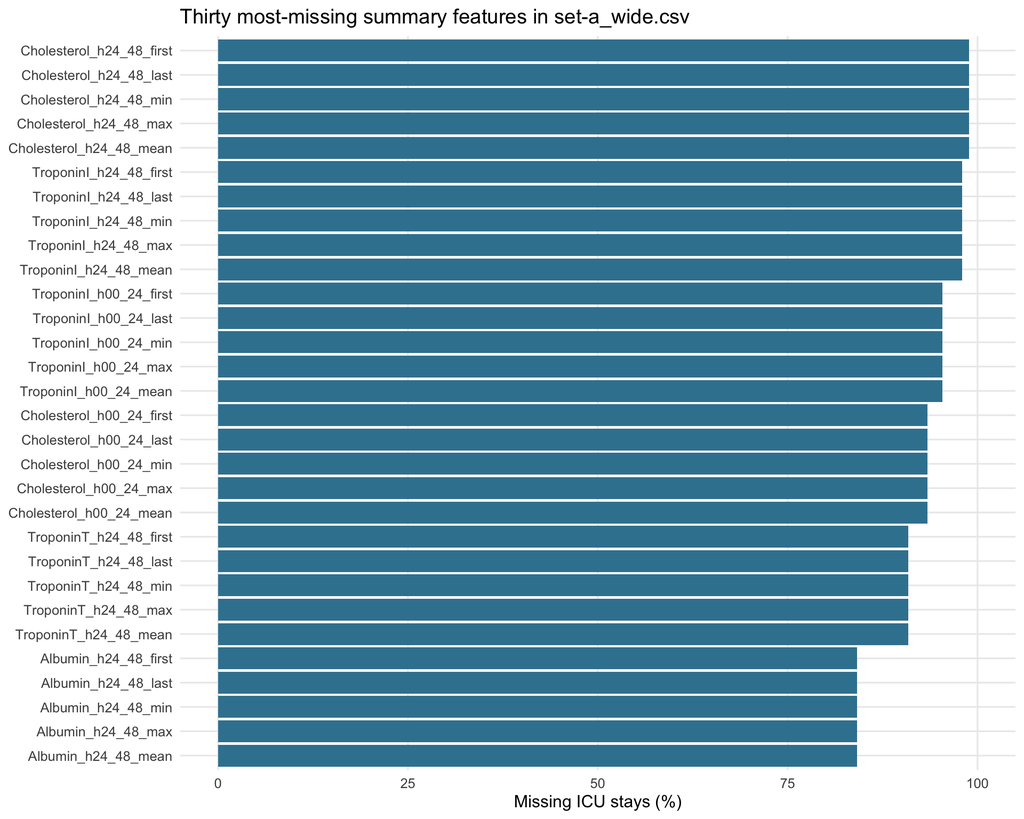

```r
ggplot(top_wide_missingness, aes(x = Missing_percent, y = Variable)) +
  geom_col(fill = "#3B82A0") +
  scale_x_continuous(limits = c(0, 100)) +
  labs(
    x = "Missing ICU stays (%)",
    y = NULL,
    title = "Thirty most-missing summary features in set-a_wide.csv"
  )
```

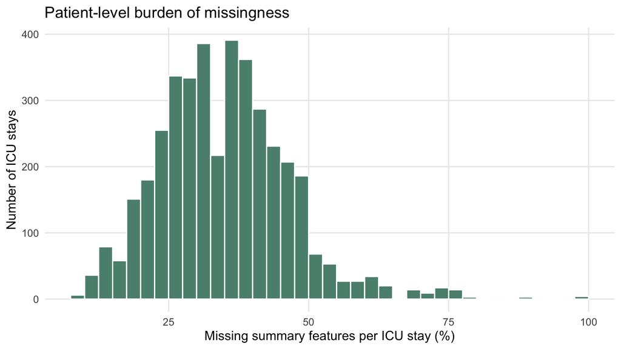

```r
ggplot(patient_missingness, aes(x = Missing_percent)) +
  geom_histogram(binwidth = 2.5, boundary = 0, fill = "#5B8E7D", color = "white") +
  labs(
    x = "Missing summary features per ICU stay (%)",
    y = "Number of ICU stays",
    title = "Patient-level burden of missingness"
  )
```

# Is missingness informative?

To examine whether measurement decisions carry outcome information, I compare the death rate between stays in which each variable was ever measured during the first 48 hours and stays in which it was never measured. This is a descriptive association, not a causal effect: ordering a test may reflect illness severity, clinical workflow, or both.

```r
dynamic_parameters <- sort(unique(analysis_long$Parameter))

measurement_flags <- long |>
  filter(
    between(Minutes, 0, 48 * 60),
    Parameter %in% dynamic_parameters,
    !is.na(Value_clean)
  ) |>
  distinct(RecordID, Parameter) |>
  mutate(ever_measured = TRUE)

measurement_grid <- tidyr::crossing(
  RecordID = id_frame$RecordID,
  Parameter = dynamic_parameters
) |>
  left_join(measurement_flags, by = c("RecordID", "Parameter")) |>
  mutate(ever_measured = replace_na(ever_measured, FALSE)) |>
  left_join(
    outcomes |> select(RecordID, In_hospital_death),
    by = "RecordID"
  )

death_by_measurement <- measurement_grid |>
  group_by(Parameter, ever_measured) |>
  summarise(
    n = n(),
    deaths = sum(In_hospital_death == 1L),
    death_rate = mean(In_hospital_death == 1L),
    .groups = "drop"
  ) |>
  complete(
    Parameter,
    ever_measured = c(FALSE, TRUE),
    fill = list(n = 0L, deaths = 0L, death_rate = NA_real_)
  )

death_association <- death_by_measurement |>
  pivot_wider(
    id_cols = Parameter,
    names_from = ever_measured,
    values_from = c(n, deaths, death_rate),
    names_sep = "_",
    names_repair = "check_unique"
  ) |>
  mutate(
    death_rate_difference = death_rate_TRUE - death_rate_FALSE
  ) |>
  arrange(desc(abs(death_rate_difference)))

readr::write_csv(
  death_association,
  file.path(out_dir, "missingness_outcome_association.csv"),
  na = ""
)

death_association |>
  filter(n_FALSE >= 20L, n_TRUE >= 20L) |>
  transmute(
    Parameter,
    `Never measured, n` = n_FALSE,
    `Measured, n` = n_TRUE,
    `Death rate, never measured (%)` = round(100 * death_rate_FALSE, 1),
    `Death rate, measured (%)` = round(100 * death_rate_TRUE, 1),
    `Difference (percentage points)` =
      round(100 * death_rate_difference, 1)
  ) |>
  slice_head(n = 20L) |>
  knitr::kable(
    caption = paste(
      "Variables with the largest absolute difference in death rate by",
      "whether they were measured (groups with at least 20 stays)"
    )
  )
```

Variables with the largest absolute difference in death rate by whether they were measured (groups with at least 20 stays)

| Parameter | Never measured, n | Measured, n | Death rate, never measured (%) | Death rate, measured (%) | Difference (percentage points) |
| --- | --- | --- | --- | --- | --- |
| TroponinI | 3795 | 205 | 13.1 | 27.8 | 14.7 |
| TroponinT | 3137 | 863 | 11.9 | 21.1 | 9.2 |
| AST | 2275 | 1725 | 9.9 | 19.1 | 9.2 |
| ALT | 2279 | 1721 | 9.9 | 19.1 | 9.1 |
| Bilirubin | 2282 | 1718 | 9.9 | 19.0 | 9.1 |
| ALP | 2310 | 1690 | 10.0 | 19.1 | 9.0 |
| WBC | 73 | 3927 | 5.5 | 14.0 | 8.5 |
| Lactate | 1817 | 2183 | 9.3 | 17.6 | 8.3 |
| Albumin | 2385 | 1615 | 10.5 | 18.8 | 8.2 |
| RespRate | 2899 | 1101 | 16.1 | 7.9 | -8.2 |
| Platelets | 68 | 3932 | 5.9 | 14.0 | 8.1 |
| Glucose | 113 | 3887 | 6.2 | 14.1 | 7.9 |
| FiO2 | 1283 | 2717 | 8.6 | 16.3 | 7.8 |
| BUN | 64 | 3936 | 6.2 | 14.0 | 7.7 |
| Creatinine | 64 | 3936 | 6.2 | 14.0 | 7.7 |
| HCT | 64 | 3936 | 6.2 | 14.0 | 7.7 |
| PaCO2 | 977 | 3023 | 8.2 | 15.7 | 7.5 |
| HCO3 | 76 | 3924 | 6.6 | 14.0 | 7.4 |
| PaO2 | 977 | 3023 | 8.3 | 15.6 | 7.4 |
| pH | 962 | 3038 | 8.3 | 15.6 | 7.3 |

These differences show that missingness is not simply random noise. They do not establish that measuring a variable changes mortality. More plausibly, test ordering and monitoring intensity encode information about patient severity, ICU workflow, and treatment decisions. In later predictive work, missingness indicators may therefore be useful features, but all imputation and feature construction must be learned inside each training fold to avoid information leakage.

# Output validation

```r
required_outputs <- c(
  file.path(out_dir, "set-a_long.csv"),
  file.path(out_dir, "set-a_wide.csv")
)

stopifnot(
  "Required CSV outputs were not created" = all(file.exists(required_outputs)),
  "Long output is empty" = file.info(required_outputs[[1]])$size > 0,
  "Wide output is empty" = file.info(required_outputs[[2]])$size > 0
)

tibble(
  Output = basename(required_outputs),
  Rows = c(nrow(set_a_long), nrow(set_a_wide)),
  Columns = c(ncol(set_a_long), ncol(set_a_wide)),
  `Size (MB)` = round(file.info(required_outputs)$size / 1024^2, 2)
) |>
  knitr::kable(caption = "Required derived data products")
```

Required derived data products

| Output | Rows | Columns | Size (MB) |
| --- | --- | --- | --- |
| set-a_long.csv | 1753980 | 10 | 79.09 |
| set-a_wide.csv | 4000 | 455 | 5.55 |

# AI-use statement

I used OpenAI Codex to help diagnose a duplicated-column-name error in `pivot_wider()`, draft boilerplate for reproducible file loading and validation, and explain several R operations. The main benefit was faster debugging and a clearer set of defensive checks. The main risk was that generated code could make incorrect assumptions about variable meaning or silently mishandle missing values. I reviewed the code line by line, checked the data dimensions and identifiers, inspected the generated tables and figures, and rendered the document using the locked pixi environment. I revised the generated suggestions where needed and remain responsible for the analysis and interpretation.